# R Notebook – gapminder data exploration

Neil Yetz

# Load Packages for this session

```r
 library(tidyverse)
```

# Import data

The gapminder dataset is provided by an organization called Gapminder.org. It contains data on 142 countries. For each country the dataset provides values for life expectancy, GDP per capita, and population - with these data available every five years from 1952 to 2007.

```r
#notes work in code chunks like normal comments
gm <- read_csv(file="gapminder.csv")
```

# Summarize the variables

```r
summary(gm)
```

```
   country           continent              year         lifeExp           pop              gdpPercap
 Length:1704        Length:1704        Min.   :1952   Min.   :23.60   Min.   :6.001e+04   Min.   :   241.2
 Class :character   Class :character   1st Qu.:1966   1st Qu.:48.20   1st Qu.:2.794e+06   1st Qu.:  1202.1
 Mode  :character   Mode  :character   Median :1980   Median :60.71   Median :7.024e+06   Median :  3531.8
                                       Mean   :1980   Mean   :59.47   Mean   :2.960e+07   Mean   :  7215.3
                                       3rd Qu.:1993   3rd Qu.:70.85   3rd Qu.:1.959e+07   3rd Qu.:  9325.5
                                       Max.   :2007   Max.   :82.60   Max.   :1.319e+09   Max.   :113523.1
```

# Explore a variety of plots

## Exploration of Desnity Plots

### A simple plot

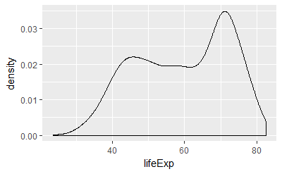

```r
ggplot(gm, aes(x=lifeExp)) + geom_density() #the "+" sign indicates we are using a new function. this is a subfunction of ggplot.
```

```r
#general format of ggplot -> ggplot(dataset, aes(x=x-variable)) + geom_density(fill="color")
#ggplot basically uses order of operations. Your parentheses need to match!!
#just a note, if you create a paragrapph, it only works after "+" signs & "," Additionay, it will auto indent places where you have created a new paragraph correctly.
```

### Change the color of the density plot

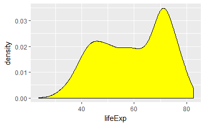

```r
ggplot(gm, aes(x = lifeExp)) +
geom_density(fill = "yellow")
```

### Add Axis labels and a Title (Also, center the title.)

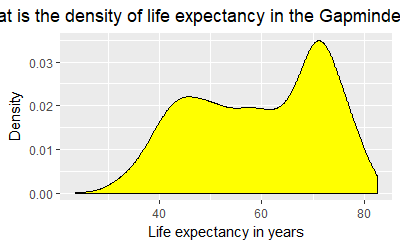

```r
theme_update(plot.title = element_text(hjust = 0.5)) #centering the title
  ggplot(gm, aes(x = lifeExp)) +
  geom_density(fill = "yellow") +
  labs(title = "What is the density of life expectancy in the Gapminder dataset?",
x = "Life expectancy in years", y = "Density")
```

# Group and fill by continent

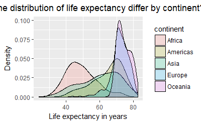

```r
#Here we are using groupign variables.
theme_update(plot.title = element_text(hjust = 0.5)) #centering the title
  ggplot(gm, aes(x = lifeExp, group = continent, fill=continent)) + #It is better to map all of your grouping variables within the aesthetic function.
  geom_density(alpha=.2) +  #alpha regulates how bright the color is in the fill the lower the number (between 0-1), the more transparent it will be.
  labs(title = "Does the distribution of life expectancy differ by continent?",
  x = "Life expectancy in years", y = "Density")
```

### Seperating our groups using facet_wrap

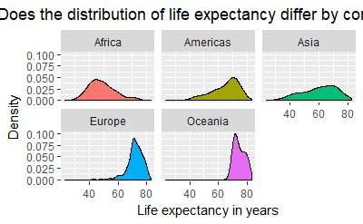

```r
ggplot(gm, aes(x = lifeExp, group =continent, fill = continent)) + #group = continent is telling us to group by contininent.
    geom_density(show.legend = FALSE) + #show.legend = FALSE removes the legend
  facet_wrap(~ continent) + #this is separating it by the group. rememebr Facet = creating separate graphs for our Groups! NOTE: YOU MUST HAVE the ~ for the facet_wrap function
  labs(title = "Does the distribution of life expectancy differ by continent?",
  x = "Life expectancy in years", y = "Density")
```

## Exploration of histograms

### A histogram similar to our last density plot.

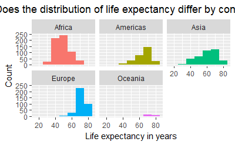

```r
ggplot(gm, aes(x = lifeExp, group =continent, fill = continent)) +
    geom_histogram(show.legend = FALSE, binwidth=10) + # <- note, we are using "geom_histogram". Additionally, we need to create a binwidth. The default for this is to take your range and divide it by 30 (this happens if you don't specify it)
  facet_wrap(~ continent) +
  labs(title = "Does the distribution of life expectancy differ by continent?",
  x = "Life expectancy in years", y = "Count")
```

### Manually set the colors for each continent

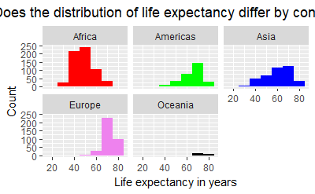

```r
ggplot(gm, aes(x = lifeExp, group =continent, fill = continent)) +
    geom_histogram(show.legend = FALSE, binwidth=10) + # <- note, we are using "geom_histogram". Additionally, we need to create a binwidth. The default for this is to take your range and divide it by 30 (this happens if you don't specify it)
  facet_wrap(~ continent) +
  labs(title = "Does the distribution of life expectancy differ by continent?",
  x = "Life expectancy in years", y = "Count") +
  scale_fill_manual(values = c("red", "green", "blue", "violet", "black")) #c() = concatenate. You use it anytime you need to create a list.
```

## Exploration of Boxplots

### A simple boxplot

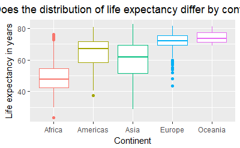

```r
ggplot(gm, aes(x = continent, y = lifeExp, group =continent, color = continent)) + #note we are using "color" instead of "fill" You can still use the fill function and it will fill the entire box.
  geom_boxplot(show.legend = FALSE) +
  labs(title = "Does the distribution of life expectancy differ by continent?",
    x = "Continent", y = "Life expectancy in years")
```

### Boxplot faceted by year

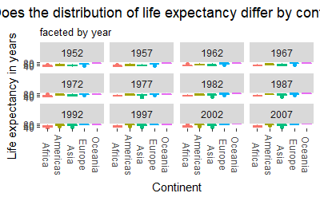

```r
ggplot(gm, aes(x = continent, y = lifeExp, group =continent, color = continent)) +
  geom_boxplot(show.legend = FALSE) +
  facet_wrap(~ year) + #faceting by year don't forget you "~"!!!!
labs(title = "Does the distribution of life expectancy differ by continent?",
subtitle = "faceted by year", x = "Continent", y = "Life expectancy in years") + #we created a subtitle!!!
theme(axis.text.x = element_text(angle=-90, vjust=.5)) #note the theme here has made it look a lot better. We have angled the labels so they are more readable (-90 degrees). "vjust" = verticle justification, it changes where your text aligns in correspondence to the graph it is representing.
```

## Exploration of Line Plots

### A line plot for each country, faceted by continent.

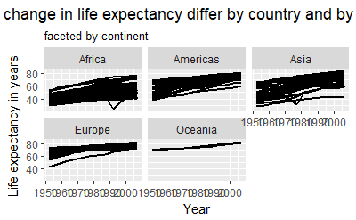

```r
ggplot(gm, aes(x = year, y = lifeExp, group = country)) +
  geom_line(lwd = 1, show.legend = FALSE) + #gemo_line = we are indicating this as a line plot. lwd = 1 means "linewidth"
  facet_wrap(~ continent) +
  labs(title = "Does change in life expectancy differ by country and by continent?",
  subtitle = "faceted by continent", x = "Year", y = "Life expectancy in years")
```

### Change the color of the lines from black to red

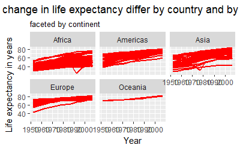

```r
ggplot(gm, aes(x = year, y = lifeExp, group = country)) +
  geom_line(lwd = 1, show.legend = FALSE, colour = "red") + #note the british spelling of color here.... the american version works too...
  facet_wrap(~ continent) +
  labs(title = "Does change in life expectancy differ by country and by continent?",
  subtitle = "faceted by continent", x = "Year", y = "Life expectancy in years")
```

### color by country within continent

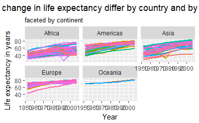

```r
ggplot(gm, aes(x = year, y = lifeExp, group = country, colour = country)) +
  geom_line(lwd = 1, show.legend = FALSE) +
  facet_wrap(~ continent) +
  labs(title = "Does change in life expectancy differ by country and by continent?",
  subtitle = "faceted by continent", x = "Year", y = "Life expectancy in years")
```

### Manually set the x axis range

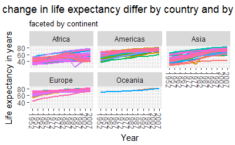

```r
ggplot(gm, aes(x = year, y = lifeExp, group = country, colour = country)) +
  geom_line(lwd = 1, show.legend = FALSE) +
  facet_wrap(~ continent) +
  labs(title = "Does change in life expectancy differ by country and by continent?",
  subtitle = "faceted by continent", x = "Year", y = "Life expectancy in years") +
    scale_x_continuous(breaks= c(1952, 1957, 1962, 1967, 1972, 1977, 1982, 1987, 1992, 1997, 2002, 2007)) +
  theme(axis.text.x = element_text(angle = -90, vjust = .5))
```

## Exploration of Scatterplots

### A simple Scatterplot

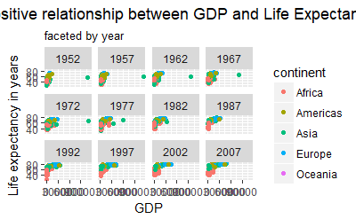

```r
ggplot(gm, aes(x = gdpPercap, y = lifeExp, group = continent, color = continent)) +
geom_point() +
facet_wrap(~ year) +
labs(title = "Is there a positive relationship between GDP and Life Expectancy?",
subtitle = "faceted by year", x = "GDP", y = "Life expectancy in years")
```

### Apply a log10 transformation to the X-axis

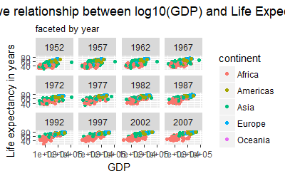

```r
ggplot(gm, aes(x = gdpPercap, y = lifeExp, group = continent, color = continent)) +
geom_point() +
facet_wrap(~ year) +
scale_x_log10() + #<- log transform your X-Axis
labs(title = "Is there a positive relationship between log10(GDP) and Life Expectancy?",
subtitle = "faceted by year", x = "GDP", y = "Life expectancy in years")
```

### Size the points by population

Note: there are multiple ways to input aesthetic functions. If it only applies to one of the elements (as opposed to all elements) it’s better to apply the aesthetic function into the geom point function.

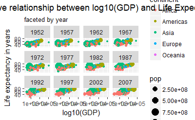

```r
ggplot(gm, aes(x = gdpPercap, y = lifeExp, group = continent, color = continent)) +
geom_point(aes(size = pop)) + # <- Here we are creating a new geom point (wrapped withing and aesthetic) sizing them by population
facet_wrap(~ year) +
scale_x_log10() + #<- log transform your X-Axis
labs(title = "Is there a positive relationship between log10(GDP) and Life Expectancy?",
subtitle = "faceted by year", x = "log10(GDP)", y = "Life expectancy in years")
```

### adding a regression line!

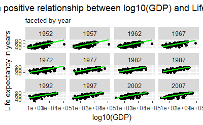

```r
ggplot(gm, aes(x = gdpPercap, y = lifeExp)) +#, group = continent, color = continent)) +
geom_point() +
  geom_smooth(method = "lm", se=FALSE, color="green") +
facet_wrap(~ year) +
scale_x_log10() + #<- log transform your X-Axis
labs(title = "Is there a positive relationship between log10(GDP) and Life Expectancy?",
subtitle = "faceted by year", x = "log10(GDP)", y = "Life expectancy in years")
```

## Exploration on bar plots

### A bar plot to display the number of data points for each contiinent

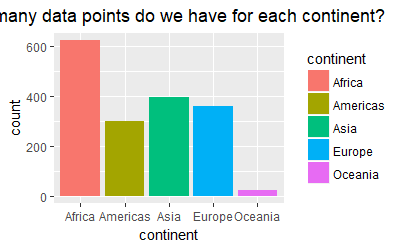

```r
ggplot(gm, aes(x = continent, fill = continent)) + geom_bar() +
labs(title = "How many data points do we have for each continent?")
```